# Index.Rmd

Jonathan Schuster

08/10/2020

### Abstract (tl;dr)

Summer 2020 Ferris State University reproducible research project looking at the Midwest Coalition States COVID death numbers/case numbers compared to states with similar population sizes.

### Introduction

This is a Summer 2020 Ferris State University project for BIOL 390 Reproducible research created by Jonathan Schuster. Data was found from several reputable datasets located from the CDC and used to better understand my hypothesis on the Midwest Coalition’s COVID 19 response. R Studio was used to clean datasets, from the CDC, which were used to make visual reputations through graphs/tables on R Markdown.

### Hypothesis

Hypothesis: On April 16, 2020 seven states joined together to form the Midwest Coalition to combat the spead of COVID 19. These states include Michigan, Ohio, Wisconsin, Minnesota, Illinois, Indiana, and Kentucky. My hypothesis is the Midwest Coalition has effectively reduced the spread of COVID since it’s creation compared to other states with similar populations such as New Jersey, Georgia, Maryland, Colorado, Pennsylvania, Tennessee, and Louisiana.

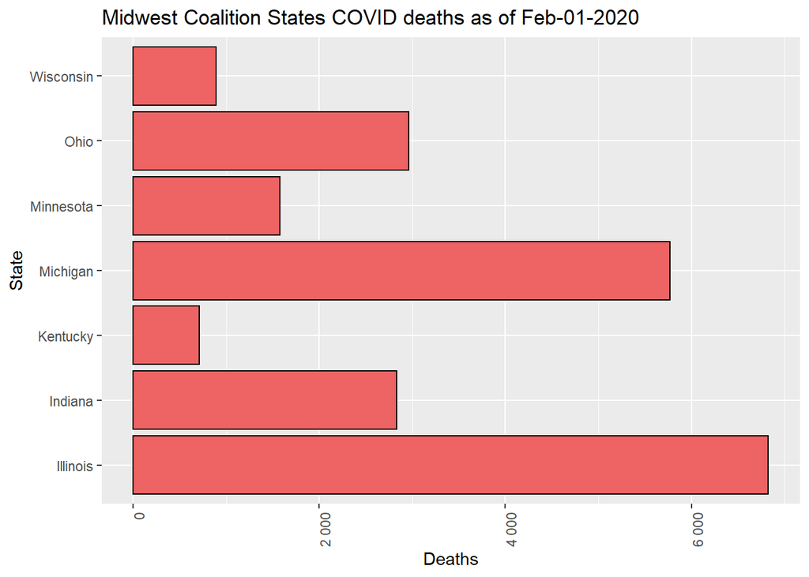

### Total Death Analysis

On April 16, 2020 seven states came together to “flatten the curve”. These states include Michigan, Ohio, Wisconsin, Minnesota, Illinois, Indiana, and Kentucky. They referred this coalition as the Midwest Coalition. On the right you will find two different graphs. On the top (Red), which will contain data on total deaths in states from the Midwest Coalition from Feb 01, 2020. On the bottom (Blue), you will find total death data from seven Non-Coalition states which include New Jersey, Georgia, Maryland, Colorado, Pennsylvania, Tennessee, and Louisiana.

#### Total Death Midwest Coalition Analysis

Furthermore, investigating the graphics to the right we can see on average Midwest Coalition states saw fewer overall deaths. The state that saw the least deaths was Kentucky at ~ 700 deaths. The state with the most deaths came out to be Illinois at ~ 6,800 deaths. Surely due to more metropolitan areas. If we were to sum up all the deaths from Midwest Coalition States since February 01, 2020 we would get ~ 21,000 total deaths.

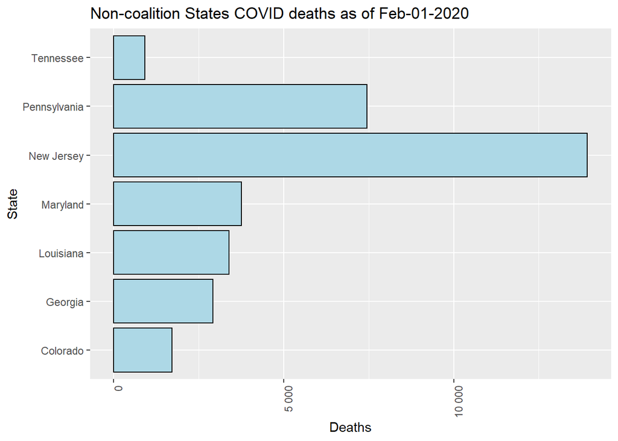

#### Total Death Non-Coalition Analysis

Investigating Non-coalition states we can see slightly more overall deaths. The state that saw the least deaths was Tennessee at ~ 900 deaths. The state with the most deaths came out to be New Jersey at ~ 14,000 deaths. If we were to sum up all the deaths from Non-coalition States since February 01, 2020 we would get ~ 34,000 total deaths. That’s over 10,000 deaths more than states residing in the Midwest Coalition.

### Total Case Analysis

Up next, I’ll be displaying information in the form of a choropleth map on total cases arising from Midwest coalition states, and Non-coalition states, respectively. Down below, you’ll find two maps focusing on the coalition and non-coalition states.

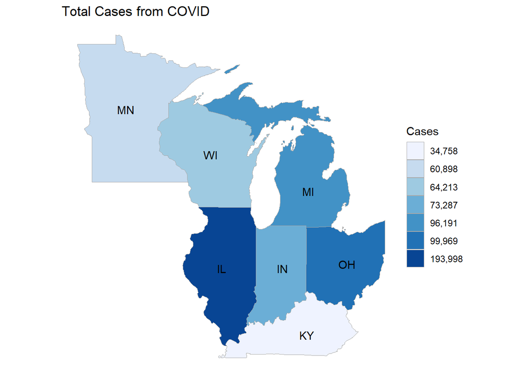

#### Total Cases Midwest Coalition Analysis

Let’s start with the visual colors. The legend tells us the numbers we are looking at describe the total amount of cases each state is seeing. The darker the color represents more cases recorded. The nice part about this graphic is the legend tells us the exact number of cases each state shows. The state in the Midwest coalition with the least reported cases is Kentucky at 34,758 cases. The state showing the most reported cases was Illinois with 193,998 cases.

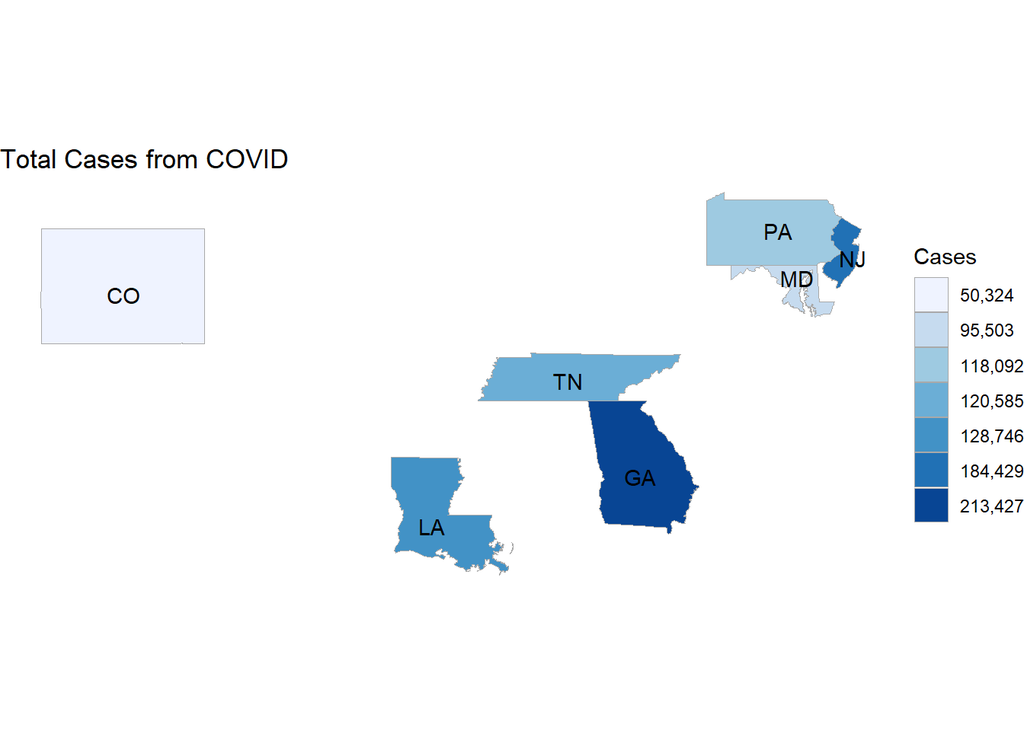

#### Total Cases Non-Coalition Analysis

Working with the same parameters as above we now see the Non-coalition data on cases. The state with the least reported cases is Colorado at 50,324 cases. The state showing the most reported cases was Georgia with 213,427 cases. Looking at only the most and least recorded states we see how Non-coalition states reported more cases on both ends of the spectrum.

### Table Analysis

#### Midwest Coalition States

Table 1: Summary of number of cases/deaths and cases in the last 7 dats for Midwest Coalition States

| jurisdiction | Cases | Deaths | CasesInLast7Days | Deaths_per_100k |
| --- | --- | --- | --- | --- |
| Illinois | 193998 | 7840 | 12241 | 62 |
| Indiana | 73287 | 3036 | 6165 | 45 |
| Kentucky | 34758 | 772 | 4035 | 17 |
| Michigan | 96191 | 6520 | 4859 | 65 |
| Minnesota | 60898 | 1698 | 4951 | 30 |
| Ohio | 99969 | 3668 | 7882 | 31 |
| Wisconsin | 64213 | 1003 | 6155 | 17 |

#### Non-coalition States

Table 2: Summary of number of cases/deaths and cases in the last 7 days for Non-coalition States

| jurisdiction | Cases | Deaths | CasesInLast7Days | Deaths_per_100k |
| --- | --- | --- | --- | --- |
| Colorado | 50324 | 1857 | 3057 | 33 |
| Georgia | 213427 | 4186 | 23415 | 40 |
| Louisiana | 128746 | 4207 | 12466 | 90 |
| Maryland | 95503 | 3585 | 5229 | 59 |
| New Jersey | 184429 | 15869 | 2400 | 178 |
| Pennsylvania | 118092 | 7313 | 5156 | 57 |
| Tennessee | 120585 | 1215 | 12401 | 18 |

### Conclusions

#### Answering the Hypothesis

Based on all of the results from the bar charts, choropleth maps, and table summaries. The formation of the Midwest Coalition has successfully responded to COVID in a positive way compared to states without a coalition. Coalition states have witnessed less reports of overall cases and less total deaths from the virus COVID 19.

#### Discussion

Some key points to note in this report. First, when selecting the non-coalition states I only considered total state populations. Each state varied between population differences anywhere from 2,000 - 1,000,000 population differences were used. For example, I used New Jersey compared to Michigan. New Jersey population is 8,958,000 and Michigan has 9,922,000. The difference comes out to 964,000. Additionally, I did not take into consideration population densities throughout each state. For example, being from Michigan I know a majority of deaths/cases come from Detroit or Wayne County. I recognize that metropolitan area’s will contain skewed data for each state. That being said this project is at an undergraduate level and I did not narrow my results as a factor. Another point to mention, would be the lack of research on whether or not the selected Non-coalition states actually do reside in a coalition (Just not in the Midwest coalition). Lastly, I am new, or a beginner, to the R language. With that being said, my coding skills held me back from summarizing current COVID data to truly give accurate insights to whether or not the Midwest Coalition truly “flattened the curve” compared to states that did not collaborate ways to slow the progress of the disease.

### References

https://www.cdc.gov/covid-data-tracker/#cases - Used Cases, and Deaths data

https://data.cdc.gov/NCHS/Provisional-COVID-19-Death-Counts-by-Place-of-Deat/uggs-hy5q - Used COVID19 Death data

https://www.nationsonline.org/oneworld/US-states-population.htm - Used to find seven states with similar population sizes as Midwest Coalition States